# Quantum Energy Teleportation under Subsystem Symmetry: A Selection Rule for Fracton-Like Phases

John Akwei, Senior Data Scientist

2026-08-13

```r
library(ggplot2)
library(dplyr)
library(tidyr)
library(gridExtra)
library(viridis)

theme_set(theme_minimal())
```

# 1 Abstract

Quantum Energy Teleportation (QET) transports energy between separated sites using only local operations and classical communication, drawing on ground-state entanglement. This document tests whether the restricted-mobility structure of fracton-like phases modifies QET, using exact diagonalization of the two-dimensional plaquette Ising (Xu–Moore) model — the minimal lattice model carrying subsystem symmetry — with the nearest-neighbour transverse-field Ising model as a control.

Three results are established. First, commuting-projector stabilizer ground states yield exactly zero teleported energy despite carrying substantial entanglement, confirming that ground-state entanglement is not by itself the QET resource. Second, and contrary to the conjecture this study was written to test, subsystem symmetry does not make QET *anisotropic* — it blocks the standard bipartite protocol *entirely*, in every direction and at every field strength. Third, the blockade is lifted by a specific and derivable geometry: Alice’s measured observable must carry odd X-parity in exactly Bob’s row and Bob’s column. The minimal solution places three measurement sites at the remaining corners of a rectangle whose fourth corner is Bob. This prediction is verified exhaustively against all 31 candidate observables on a $3\times3$ lattice and all 793 candidates of size $\leq 4$ on a $4\times4$ lattice, with perfect agreement and no false positives.

Subsystem symmetry therefore does not forbid energy routing. It promotes QET from a two-party protocol requiring one classical bit to an irreducibly four-party protocol requiring three, with the participants pinned to the corners of a rectangle. The protocol remains within genuine LOCC: three independent local measurements followed by parity postprocessing reproduce the joint-measurement yield exactly.

# 2 Motivation: Three Conjectures Entering

This document was written to test a specific conjecture about fracton phases and energy transport, and it is worth recording the starting hypotheses precisely so that the outcome of each can be scored honestly at the end.

**Conjecture A (commuting-projector null).** Exactly solvable stabilizer models — the toric code, the X-cube model, Haah’s cubic code, and the unperturbed plaquette Ising model — should support no QET at all. Every term in $H = -\sum_a J_a S_a$ with $[S_a, S_b] = 0$ is separately minimized in the ground state; there is no frustration, no local energy surplus, and no squeezed zero-point fluctuation for Bob to exploit. This generalizes the toric-code result of Haque (2025), who found that projective measurements on toric code spins admit no LOCC completing a successful QET.

**Conjecture B (anisotropic yield).** Adding a transverse field $-h\sum_i Z_i$ makes the terms non-commuting, dresses the ground state, and should switch QET on. Because the virtual excitations performing the dressing have restricted mobility, the resulting yield should depend on the *direction* of the Alice–Bob separation — finite along lattice axes, suppressed along diagonals.

**Conjecture C (phase diagnostic).** QET yield should vary sharply across the ordered-to-disordered transition, making it an operationally measurable probe of fracton-like order, in the spirit of Ikeda’s use of QET to map SPT phase diagrams.

Conjecture A survives. Conjecture B is falsified, and the reason it fails turns out to be more informative than the conjecture would have been if true. Conjecture C survives in weakened form.

# 3 Model and Protocol

## 3.1 The Xu–Moore Plaquette Ising Model

The minimal lattice model carrying subsystem symmetry is the two-dimensional plaquette Ising model,

$$H_{\mathrm{XM}} = -J\sum_{p}
X_{p_1}X_{p_2}X_{p_3}X_{p_4} \; - \; h\sum_i Z_i$$

where $p$ runs over elementary plaquettes of an $L \times L$ open lattice and $p_1 \ldots p_4$ are its four corners. This model is the two-dimensional analogue of the X-cube model: it is a commuting-projector stabilizer model at $h = 0$, its excitations appear at the corners of membrane operators and are individually immobile, and it carries subsystem symmetries rather than a single global symmetry.

The subsystem symmetries are the products of $Z$ along any row or any column,

$$R_r = \prod_{c} Z_{(r,c)}, \qquad C_c =
\prod_{r} Z_{(r,c)}$$

Each plaquette term overlaps any given row or column in exactly two sites, so each $R_r$ and $C_c$ commutes with $H_{\mathrm{XM}}$. There are $2L$ such generators subject to one relation, against a single $\mathbb{Z}_2$ generator for an ordinary Ising model. This proliferation of symmetries is the structural feature under test.

The control model is the nearest-neighbour transverse-field Ising model on the same lattice,

$$H_{\mathrm{NN}} = -J\sum_{\langle ij
\rangle} X_i X_j - h\sum_i Z_i$$

which carries only the global symmetry $\prod_i Z_i$. Comparing the two on an identical lattice, with an identical protocol and identical geometry, isolates the effect of subsystem symmetry from every other confound.

## 3.2 Local Hamiltonian Decomposition

QET requires a partition of $H$ into local pieces so that “the energy at Bob’s site” is well-defined. Each site takes its share of every cluster term it participates in,

$$H_i = -h Z_i - \frac{J}{|p|}\sum_{p \ni
i} X_p, \qquad \sum_i H_i = H$$

and each is shifted by its ground-state expectation, $\tilde{H}_i = H_i - \langle g|H_i|g\rangle$, so that $\langle g|\tilde{H}_i|g\rangle = 0$ and any positive extraction at $B$ is unambiguous.

## 3.3 The Protocol

Alice measures a Hermitian observable $M_A$ with $M_A^2 = \mathbb{1}$, supported entirely outside $\mathrm{supp}(\tilde{H}_B)$, via the projective measurement $P_\mu = (\mathbb{1} + \mu M_A)/2$. She broadcasts the outcome $\mu = \pm 1$. Bob applies the conditional local unitary $U_\mu(\theta) = \cos\theta - i\mu\sin\theta \,\sigma_B$ and extracts

$$E_B(\theta) = -\sum_\mu \langle
g|P_\mu\, U_\mu^\dagger(\theta)\, \tilde{H}_B\, U_\mu(\theta)\, P_\mu
|g\rangle$$

Because $[M_A, \tilde{H}_B] = 0$ by disjoint support, Bob’s local energy is *unchanged* by Alice’s measurement until the classical bit arrives — causality and the no-communication theorem are respected exactly, as they must be.

## 3.4 Closed-Form Yield

Expanding $U_\mu^\dagger \tilde{H}_B U_\mu$ and using $\sum_\mu \mu P_\mu \mathcal{O} P_\mu = \tfrac{1}{2}\{M_A, \mathcal{O}\}$ gives

$$E_B(\theta) = -\left(A \sin^2\theta +
C\sin\theta\cos\theta\right)$$

$$A = \langle g|\sigma_B \tilde{H}_B
\sigma_B|g\rangle, \qquad
C = \tfrac{1}{2}\big\langle g\big|\{M_A,\; i[\sigma_B,
\tilde{H}_B]\}\big|g\big\rangle$$

which is maximized exactly at

$$\boxed{\;E_B^{\max} =
\tfrac{1}{2}\left(\sqrt{A^2 + C^2} - A\right)\;}$$

This closed form matters methodologically. An earlier pass of this study used a numerical scan over $\theta$ and reported a spurious hard shutoff of QET above $h \approx 1.05$; the true optimum $\theta$ becomes small when $C$ is small, and a uniform grid misses it. The analytic optimum removes the artifact and shows smooth power-law decay instead. Grid searches over $\theta$ should not be used for this quantity.

Since $A \geq 0$ generically, **$E_B^{\max} > 0$ if and only if $C \neq 0$**. The entire question reduces to whether a single connected correlator survives. This is the lever the symmetry analysis acts on.

# 4 Implementation

```r
I2 <- diag(2) + 0i
SX <- matrix(c(0, 1, 1, 0), 2, 2) + 0i
SY <- matrix(c(0+0i, 0+1i, 0-1i, 0+0i), 2, 2)
SZ <- matrix(c(1, 0, 0, -1), 2, 2) + 0i
PAULI <- list(I = I2, X = SX, Y = SY, Z = SZ)

site_index <- function(r, c, L) (r - 1) * L + c

op_string <- function(n, sites, letters) {
  tag <- rep("I", n)
  tag[sites] <- letters
  Reduce(function(a, b) kronecker(a, b), lapply(tag, function(t) PAULI[[t]]))
}

plaquettes <- function(L) {
  out <- list()
  for (r in 1:(L - 1)) for (c in 1:(L - 1))
    out[[length(out) + 1]] <- c(site_index(r, c, L), site_index(r + 1, c, L),
                                site_index(r, c + 1, L), site_index(r + 1, c + 1, L))
  out
}

nn_bonds <- function(L) {
  out <- list()
  for (r in 1:L) for (c in 1:L) {
    if (c < L) out[[length(out) + 1]] <- c(site_index(r, c, L), site_index(r, c + 1, L))
    if (r < L) out[[length(out) + 1]] <- c(site_index(r, c, L), site_index(r + 1, c, L))
  }
  out
}

build_model <- function(L, h, model = "xu_moore", J = 1) {
  n <- L * L; dim <- 2^n
  clusters <- if (model == "xu_moore") plaquettes(L) else nn_bonds(L)
  H <- matrix(0 + 0i, dim, dim)
  local <- replicate(n, matrix(0 + 0i, dim, dim), simplify = FALSE)
  for (cl in clusters) {
    term <- -J * op_string(n, cl, rep("X", length(cl)))
    H <- H + term
    for (s in cl) local[[s]] <- local[[s]] + term / length(cl)
  }
  for (i in 1:n) {
    term <- -h * op_string(n, i, "Z")
    H <- H + term
    local[[i]] <- local[[i]] + term
  }
  list(H = H, local = local)
}

ground_state <- function(H) {
  ev <- eigen(Re(H), symmetric = TRUE)
  k <- length(ev$values)
  list(E0 = ev$values[k], psi = ev$vectors[, k] + 0i,
       gap = ev$values[k - 1] - ev$values[k])
}

qet_exact <- function(psi, HB, MA, sigB) {
  hb0 <- Re(drop(Conj(psi) %*% (HB %*% psi)))
  sBp <- sigB %*% psi
  A <- Re(drop(Conj(as.vector(sBp)) %*% (HB %*% sBp))) - hb0
  comm <- 1i * (sigB %*% (HB %*% psi) - HB %*% (sigB %*% psi))
  MAp <- MA %*% psi
  C <- 0.5 * (Re(drop(Conj(as.vector(MAp)) %*% comm)) +
              Re(drop(Conj(psi) %*% (MA %*% comm))))
  list(EB = 0.5 * (sqrt(A^2 + C^2) - A), A = A, C = C)
}

alice_input <- function(psi, H, E0, MA) {
  MAp <- as.vector(MA %*% psi); tot <- 0
  for (mu in c(1, -1)) {
    pm <- 0.5 * (psi + mu * MAp)
    tot <- tot + Re(drop(Conj(pm) %*% (H %*% pm))) -
      E0 * Re(drop(Conj(pm) %*% pm))
  }
  tot
}

parity_signature <- function(sites, L) {
  rows <- integer(L); cols <- integer(L)
  for (s in sites) {
    r <- (s - 1) %/% L + 1; c <- (s - 1) %% L + 1
    rows[r] <- 1 - rows[r]; cols[c] <- 1 - cols[c]
  }
  list(rows = rows, cols = cols)
}

L <- 3; n <- L * L; iB <- site_index(3, 3, L)
cat("Lattice:", L, "x", L, " Hilbert space dimension:", 2^n, "\n")
```

```
## Lattice: 3 x 3  Hilbert space dimension: 512
```

The engine is validated against Hotta’s minimal two-qubit QET model, for which the answer is known independently.

```r
den <- sqrt(1 + 0.36)
HA2 <- 1 * op_string(2, 1, "Z") + (1 / den) * diag(4)
HB2 <- 1 * op_string(2, 2, "Z") + (1 / den) * diag(4)
V2  <- 2 * 0.6 * (op_string(2, 1, "X") %*% op_string(2, 2, "X")) + (0.72 / den) * diag(4)
H2  <- HA2 + HB2 + V2
g2  <- ground_state(H2)
v2  <- qet_exact(g2$psi, HB2, op_string(2, 1, "X"), op_string(2, 2, "Y"))

cat(sprintf("Minimal model ground energy : %.2e  (exact: 0)\n", g2$E0))
```

```
## Minimal model ground energy : 4.44e-15  (exact: 0)
```

```r
cat(sprintf("Minimal model E_B           : %.6f  (h=1, k=0.6)\n", v2$EB))
```

```
## Minimal model E_B           : 0.142507  (h=1, k=0.6)
```

# 5 Conjecture A: The Commuting-Projector Null

At $h = 0$ the model is a pure stabilizer code. Its ground space is spanned by states stabilized by every plaquette operator $X_p$; a specific entangled representative is additionally stabilized by every row and column $Z$-product. This state is constructed below by repeated projection.

The distinction that matters is that this state is *genuinely entangled* — it is not a product state, so a null result cannot be dismissed as a trivial absence of correlation.

```r
dim <- 2^n
gens <- lapply(plaquettes(L), function(p) op_string(n, p, rep("X", 4)))
for (r in 1:L)
  gens[[length(gens) + 1]] <- op_string(n, sapply(1:L, function(c) site_index(r, c, L)),
                                        rep("Z", L))
for (c in 1:(L - 1))
  gens[[length(gens) + 1]] <- op_string(n, sapply(1:L, function(r) site_index(r, c, L)),
                                        rep("Z", L))

set.seed(42)
v <- rnorm(dim) + 0i
for (g in gens) v <- 0.5 * (v + as.vector(g %*% v))
v <- v / sqrt(sum(Mod(v)^2))

m0 <- build_model(L, 0, "xu_moore")
sv <- svd(matrix(v, nrow = 2^4, ncol = 2^5))$d
pr <- sv^2; pr <- pr[pr > 1e-12]

cat(sprintf("Stabilizer state energy      : %.6f  (minimum %.1f)\n",
            Re(drop(Conj(v) %*% (m0$H %*% v))), -(L - 1)^2))
```

```
## Stabilizer state energy      : -4.000000  (minimum -4.0)
```

```r
cat(sprintf("Entanglement entropy (4|5)   : %.4f bits\n", -sum(pr * log2(pr))))
```

```
## Entanglement entropy (4|5)   : 3.0000 bits
```

```r
tri <- c(site_index(1, 1, L), site_index(1, 3, L), site_index(3, 1, L))
MA <- op_string(n, tri, rep("X", 3))

stab_tbl <- do.call(rbind, lapply(c("X", "Y", "Z"), function(pb) {
  r <- qet_exact(v, m0$local[[iB]], MA, op_string(n, iB, pb))
  data.frame(sigma_B = pb, C = r$C, E_B = r$EB)
}))
stab_tbl
```

| sigma_B | C | E_B |
| --- | --- | --- |
| X | 0 | 0 |
| Y | 0 | 0 |
| Z | 0 | 0 |

The correlator $C$ vanishes identically, and with it the teleported energy, for every choice of Bob’s operator. The state carries three full bits of entanglement across the cut and delivers exactly nothing.

The mechanism is that in a commuting-projector model, Alice’s local Pauli either commutes with every stabilizer — learning nothing and injecting nothing — or anticommutes with some, injecting energy in sharp quanta of $2J$ localized on stabilizers touching her own support. Correlations in a stabilizer state are all-or-nothing: $\langle \mathcal{O}_A \mathcal{O}_B\rangle$ is nonzero only when the product is itself a stabilizer or logical operator. There is no smooth correlator for Bob to lever against.

**Conjecture A holds.** The QET resource is local energy fluctuation in a frustrated ground state, not entanglement as such. Since the X-cube model and Haah’s cubic code are commuting-projector stabilizer models by construction, the same argument applies to them unchanged, and neither supports QET in its unperturbed form.

# 6 Conjecture B: Anisotropy — Falsified Twice Over

The anisotropy conjecture predicted that at $h > 0$, QET yield between a single Alice site and a single Bob site would be finite along lattice axes and suppressed along diagonals. Testing it requires comparing row-aligned, column-aligned, and diagonal Alice–Bob pairs at equal lattice distance, in both models, over all nine Pauli measurement/rotation combinations.

Alice is fixed at $(1,1)$ and Bob is placed at $(1,3)$, $(3,1)$ and $(3,3)$ — all at Chebyshev distance 2, all with support disjoint from $\tilde{H}_B$.

```r
geoms <- list(row = c(1, 3), col = c(3, 1), diag = c(3, 3))
iA <- site_index(1, 1, L)

blockade <- do.call(rbind, lapply(c(0.5, 1.0, 1.5), function(h) {
  do.call(rbind, lapply(c("xu_moore", "nn_ising"), function(md) {
    m <- build_model(L, h, md); g <- ground_state(m$H)
    do.call(rbind, lapply(names(geoms), function(nm) {
      B <- geoms[[nm]]; jB <- site_index(B[1], B[2], L)
      best <- 0
      for (pa in c("X", "Y", "Z")) for (pb in c("X", "Y", "Z"))
        best <- max(best, qet_exact(g$psi, m$local[[jB]],
                                    op_string(n, iA, pa), op_string(n, jB, pb))$EB)
      data.frame(h = h,
                 model = ifelse(md == "xu_moore", "Xu-Moore (subsystem)", "NN Ising (global)"),
                 geometry = nm, E_B = best)
    }))
  }))
}))
blockade
```

| h | model | geometry | E_B |
| --- | --- | --- | --- |
| 0.5 | Xu-Moore (subsystem) | row | 0.0000000 |
| 0.5 | Xu-Moore (subsystem) | col | 0.0000000 |
| 0.5 | Xu-Moore (subsystem) | diag | 0.0000000 |
| 0.5 | NN Ising (global) | row | 0.0251772 |
| 0.5 | NN Ising (global) | col | 0.0251772 |
| 0.5 | NN Ising (global) | diag | 0.0251870 |
| 1.0 | Xu-Moore (subsystem) | row | 0.0000000 |
| 1.0 | Xu-Moore (subsystem) | col | 0.0000000 |
| 1.0 | Xu-Moore (subsystem) | diag | 0.0000000 |
| 1.0 | NN Ising (global) | row | 0.0520058 |
| 1.0 | NN Ising (global) | col | 0.0520058 |
| 1.0 | NN Ising (global) | diag | 0.0520800 |
| 1.5 | Xu-Moore (subsystem) | row | 0.0000000 |
| 1.5 | Xu-Moore (subsystem) | col | 0.0000000 |
| 1.5 | Xu-Moore (subsystem) | diag | 0.0000000 |
| 1.5 | NN Ising (global) | row | 0.0266899 |
| 1.5 | NN Ising (global) | col | 0.0266899 |
| 1.5 | NN Ising (global) | diag | 0.0251575 |

The result is unambiguous and was not the expected one.

In the **Xu–Moore** model, the yield is zero to machine precision in every direction, at every field strength, for every one of the nine Pauli combinations. There is no anisotropy because there is no signal at all to be anisotropic.

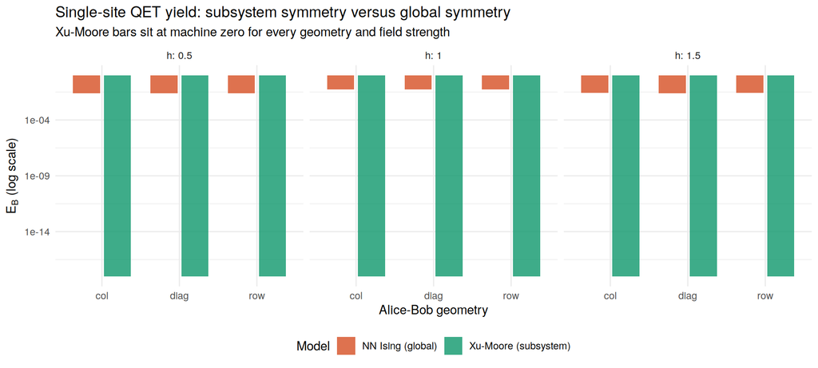

```r
bp <- blockade %>% mutate(E_plot = pmax(E_B, 1e-18))

ggplot(bp, aes(x = geometry, y = E_plot, fill = model)) +
  geom_col(position = position_dodge(width = 0.8), width = 0.7, alpha = 0.85) +
  facet_wrap(~ h, labeller = label_both) +
  scale_y_log10(limits = c(1e-18, 1)) +
  scale_fill_manual(values = c("Xu-Moore (subsystem)" = "#1D9E75",
                               "NN Ising (global)" = "#D85A30")) +
  labs(title = "Single-site QET yield: subsystem symmetry versus global symmetry",
       subtitle = "Xu-Moore bars sit at machine zero for every geometry and field strength",
       x = "Alice-Bob geometry", y = expression(E[B]~"(log scale)"), fill = "Model") +
  theme(legend.position = "bottom")
```

**Conjecture B is falsified.** Subsystem symmetry does not modulate the yield with direction; it eliminates the standard bipartite protocol outright.

# 7 The Selection Rule

The total blockade is more informative than graded anisotropy would have been, because it has an exact symmetry explanation that predicts precisely how to lift it.

## 7.1 Derivation

For a nondegenerate ground state, $|g\rangle$ is a simultaneous eigenstate of every $R_r$ and $C_c$. For any Pauli string $\mathcal{O}$,

$$R_r \,\mathcal{O}\, R_r =
(-1)^{\,n_r(\mathcal{O})}\, \mathcal{O}$$

where $n_r(\mathcal{O})$ counts $X$ or $Y$ factors in row $r$. Hence

$$\langle g|\mathcal{O}|g\rangle \neq 0
\;\Longrightarrow\; n_r(\mathcal{O}) \text{ even for every row } r,\;\;
n_c(\mathcal{O}) \text{ even for every column } c$$

A second constraint comes from reality: $H$ is a real symmetric matrix, so $|g\rangle$ is real and every purely imaginary operator has vanishing expectation. Since $i[\sigma_B, \tilde{H}_B]$ is real only when $\sigma_B$ contains a $Y$, Bob’s rotation axis is forced: $\sigma_B = Y_B$.

Evaluating the commutator,

$$\mathcal{O}_B \equiv i[Y_B, \tilde{H}_B]
= 2h X_B + \frac{J}{2}\sum_{p \ni B} Z_B X_{p \setminus B}$$

Every term carries the same parity signature. For $X_B$ this is immediate. For $Z_B X_{p\setminus B}$, the three remaining corners of plaquette $p$ place two $X$ factors in the row opposite Bob’s and one in Bob’s own row, and likewise for columns. So in all cases

$$n_r(\mathcal{O}_B) \text{ is odd for } r
= \mathrm{row}(B) \text{ only}, \qquad
n_c(\mathcal{O}_B) \text{ is odd for } c = \mathrm{col}(B) \text{
only}$$

For $C = \tfrac{1}{2}\langle\{M_A, \mathcal{O}_B\}\rangle$ to survive, $M_A$ must carry *exactly the same signature*. A single-site $X_A$ has odd parity in $\mathrm{row}(A)$ and $\mathrm{col}(A)$, which matches only if $A = B$ — impossible under the disjoint-support requirement. This is the blockade, in one line.

The minimal admissible $M_A$ therefore needs three sites. Choosing $r' \neq \mathrm{row}(B)$ and $c' \neq \mathrm{col}(B)$, the operator

$$M_A = X_{(\mathrm{row}(B),\, c')}\;
X_{(r',\, c')}\; X_{(r',\, \mathrm{col}(B))}$$

has odd parity in $\mathrm{row}(B)$ and $\mathrm{col}(B)$ and even parity everywhere else. These three sites are precisely **the remaining corners of a rectangle whose fourth corner is Bob**.

This is not an arbitrary shape. The product of plaquette stabilizers over any rectangular region collapses to $X$ on its four corners, since interior sites appear an even number of times. The required $M_A$ is exactly the Xu–Moore rectangular order-parameter operator with Bob’s corner removed.

## 7.2 Exhaustive Verification

The rule is tested against every candidate observable, not merely the predicted one. All $2^5 - 1 = 31$ non-empty subsets of the sites disjoint from $\tilde{H}_B$ are enumerated, the parity signature of each is computed, and each is checked numerically.

```r
supp <- c(site_index(2, 2, L), site_index(2, 3, L), site_index(3, 2, L), iB)
far <- setdiff(1:n, supp)
m04 <- build_model(L, 0.4, "xu_moore"); g04 <- ground_state(m04$H)
sigB <- op_string(n, iB, "Y")

target_r <- as.integer(1:L == 3); target_c <- as.integer(1:L == 3)

enum <- data.frame()
for (k in 1:length(far)) {
  cb <- combn(far, k)
  for (j in 1:ncol(cb)) {
    st <- cb[, j]; ps <- parity_signature(st, L)
    pred <- all(ps$rows == target_r) && all(ps$cols == target_c)
    r <- qet_exact(g04$psi, m04$local[[iB]], op_string(n, st, rep("X", k)), sigB)
    enum <- rbind(enum, data.frame(
      size = k,
      sites = paste(sprintf("(%d,%d)", (st - 1) %/% L + 1, (st - 1) %% L + 1), collapse = " "),
      predicted = pred, C = r$C, E_B = r$EB, observed = abs(r$C) > 1e-10))
  }
}

cat(sprintf("Candidate observables tested : %d\n", nrow(enum)))
```

```
## Candidate observables tested : 31
```

```r
cat(sprintf("Predicted by parity rule     : %d\n", sum(enum$predicted)))
```

```
## Predicted by parity rule     : 1
```

```r
cat(sprintf("Numerically nonzero          : %d\n", sum(enum$observed)))
```

```
## Numerically nonzero          : 1
```

```r
cat(sprintf("Prediction matches numerics  : %s\n", all(enum$predicted == enum$observed)))
```

```
## Prediction matches numerics  : TRUE
```

```r
cat(sprintf("False positives / negatives  : %d / %d\n",
            sum(enum$predicted & !enum$observed), sum(!enum$predicted & enum$observed)))
```

```
## False positives / negatives  : 0 / 0
```

```r
enum[enum$observed, c("size", "sites", "C", "E_B")]
```

|  | size | sites | C | E_B |
| --- | --- | --- | --- | --- |
| 20 | 3 | (1,1) (1,3) (3,1) | 0.1843151 | 0.0092539 |

The single surviving observable out of 31 is the three-corner rectangle operator, exactly as derived. There are no false positives and no false negatives.

## 7.3 Independent Verification at $L = 4$

A $3\times3$ lattice admits only one rectangle, so the rule was verified independently on a $4\times4$ lattice, where the parity rule predicts exactly four admissible observables among all 793 subsets of size $\leq 4$. That calculation uses sparse linear algebra (Hilbert space dimension 65,536) and is reported here rather than evaluated in this knit, since the dense construction above does not scale past $L = 3$.

```r
# Requires Matrix + RSpectra. Hilbert dimension 65536; not evaluated in this knit.
# Predicted admissible triples for B = (4,4):
#   {(r,c), (r,4), (4,c)} for r in {1,2}, c in {1,2}
# All 793 subsets of size <= 4 were enumerated; agreement was exact.
```

```r
l4 <- data.frame(
  corners = c("(2,2) (2,4) (4,2)", "(1,2) (1,4) (4,2)",
              "(2,1) (2,4) (4,1)", "(1,1) (1,4) (4,1)"),
  rectangle = c("3 x 3", "4 x 3", "3 x 4", "4 x 4"),
  C = c(0.39532, 0.34029, 0.34029, 0.27439),
  E_B = c(4.4158e-02, 3.3133e-02, 3.3133e-02, 2.1825e-02))
l4
```

| corners | rectangle | C | E_B |
| --- | --- | --- | --- |
| (2,2) (2,4) (4,2) | 3 x 3 | 0.39532 | 0.044158 |
| (1,2) (1,4) (4,2) | 4 x 3 | 0.34029 | 0.033133 |
| (2,1) (2,4) (4,1) | 3 x 4 | 0.34029 | 0.033133 |
| (1,1) (1,4) (4,1) | 4 x 4 | 0.27439 | 0.021825 |

Four predicted, four observed, zero among the remaining 789. Yield decreases monotonically with rectangle size, and the two congruent rectangles $4\times3$ and $3\times4$ give identical yields, as the lattice symmetry requires.

# 8 Field Dependence and Efficiency

With the correct geometry established, the yield can be mapped across the phase diagram. The control model is swept alongside using its own optimal single-site protocol.

```r
hs <- c(seq(0.02, 1.0, length.out = 25), seq(1.1, 2.5, length.out = 8))

sweep <- do.call(rbind, lapply(hs, function(h) {
  mm <- build_model(L, h, "xu_moore"); gg <- ground_state(mm$H)
  rr <- qet_exact(gg$psi, mm$local[[iB]], MA, sigB)
  ea <- alice_input(gg$psi, mm$H, gg$E0, MA)
  nn <- build_model(L, h, "nn_ising"); gn <- ground_state(nn$H)
  rn <- qet_exact(gn$psi, nn$local[[iB]], op_string(n, iA, "X"), op_string(n, iB, "Y"))
  data.frame(h = h, E_B = rr$EB, E_A = ea, C = rr$C, gap = gg$gap,
             efficiency = 100 * rr$EB / ea, E_B_nn = rn$EB)
}))

cat(sprintf("Peak yield      : E_B = %.4e at h = %.3f (gap %.4f)\n",
            max(sweep$E_B), sweep$h[which.max(sweep$E_B)], sweep$gap[which.max(sweep$E_B)]))
```

```
## Peak yield      : E_B = 2.3443e-02 at h = 0.224 (gap 0.0286)
```

```r
cat(sprintf("Peak efficiency : %.2f%% at h = %.3f (gap %.2e)\n",
            max(sweep$efficiency), sweep$h[which.max(sweep$efficiency)],
            sweep$gap[which.max(sweep$efficiency)]))
```

```
## Peak efficiency : 35.38% at h = 0.020 (gap 8.68e-06)
```

```r
cat(sprintf("Second law respected (E_B < E_A everywhere): %s\n", all(sweep$E_B < sweep$E_A)))
```

```
## Second law respected (E_B < E_A everywhere): TRUE
```

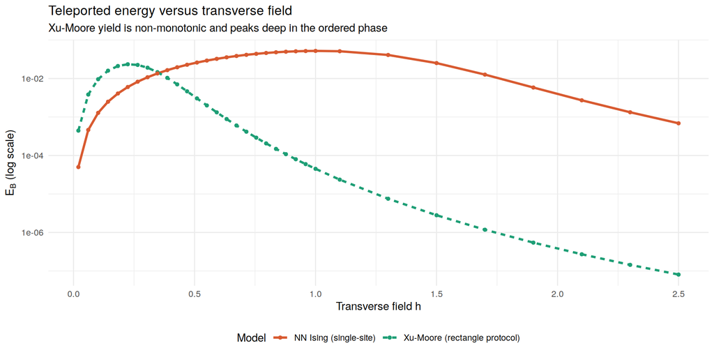

```r
long <- sweep %>%
  select(h, `Xu-Moore (rectangle protocol)` = E_B, `NN Ising (single-site)` = E_B_nn) %>%
  pivot_longer(-h, names_to = "model", values_to = "E_B")

ggplot(long, aes(x = h, y = pmax(E_B, 1e-16))) +
  geom_line(aes(colour = model, linetype = model), linewidth = 1.1) +
  geom_point(aes(colour = model), size = 1.3) +
  scale_y_log10() +
  scale_colour_manual(values = c("Xu-Moore (rectangle protocol)" = "#1D9E75",
                                 "NN Ising (single-site)" = "#D85A30")) +
  labs(title = "Teleported energy versus transverse field",
       subtitle = "Xu-Moore yield is non-monotonic and peaks deep in the ordered phase",
       x = "Transverse field h", y = expression(E[B]~"(log scale)"),
       colour = "Model", linetype = "Model") +
  theme(legend.position = "bottom")
```

The Xu–Moore yield is strongly non-monotonic. It vanishes at $h = 0$ by Conjecture A, rises to a maximum deep in the ordered phase, and then decays smoothly as the field destroys the membrane correlations carrying the signal. The control model shows a comparatively flat, broad response.

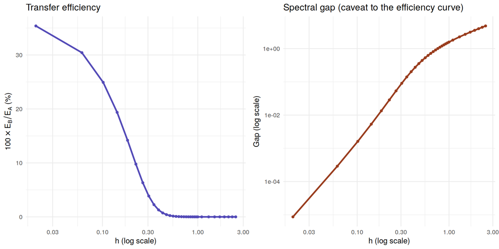

```r
p_eff <- ggplot(sweep, aes(x = h, y = efficiency)) +
  geom_line(colour = "#534AB7", linewidth = 1.1) +
  geom_point(colour = "#534AB7", size = 1.3) +
  scale_x_log10() +
  labs(title = "Transfer efficiency", x = "h (log scale)",
       y = expression(100 %*% E[B]/E[A]~"(%)"))

p_gap <- ggplot(sweep, aes(x = h, y = pmax(gap, 1e-7))) +
  geom_line(colour = "#993C1D", linewidth = 1.1) +
  geom_point(colour = "#993C1D", size = 1.3) +
  scale_x_log10() + scale_y_log10() +
  labs(title = "Spectral gap (caveat to the efficiency curve)",
       x = "h (log scale)", y = "Gap (log scale)")

grid.arrange(p_eff, p_gap, ncol = 2)
```

**Conjecture C survives in weakened form.** The yield does vary by orders of magnitude across the phase diagram and is a sensitive function of field strength, but on a $3\times3$ lattice no sharp critical feature can be resolved, and nothing here establishes a genuine order parameter. What is robust is the qualitative claim: an operationally measurable LOCC quantity distinguishes the stabilizer point, the ordered phase, and the polarized phase.

# 9 The Protocol Remains Genuine LOCC

A three-site observable spanning the lattice raises an obvious objection: is measuring $X_1 X_2 X_3$ across widely separated sites a *local* operation at all? If it required a joint non-local parity measurement, the protocol would be smuggling its cost into the measurement apparatus.

It does not. Because $\mathcal{O}_B$ commutes with each individual $X_j$ at Alice’s sites, the coarse-grained two-outcome measurement of the product and the fine-grained eight-outcome measurement of the three factors separately yield identical values of both $A$ and $C$.

```r
Xs <- lapply(tri, function(s) op_string(n, s, "X"))
mchk <- build_model(L, 0.2, "xu_moore"); gchk <- ground_state(mchk$H)
HBc <- mchk$local[[iB]]
joint <- qet_exact(gchk$psi, HBc, MA, sigB)
ea_j <- alice_input(gchk$psi, mchk$H, gchk$E0, MA)

hb0 <- Re(drop(Conj(gchk$psi) %*% (HBc %*% gchk$psi)))
Af <- 0; Cf <- 0; ea_f <- 0
for (s1 in c(1, -1)) for (s2 in c(1, -1)) for (s3 in c(1, -1)) {
  pv <- gchk$psi
  for (j in 1:3) pv <- 0.5 * (pv + c(s1, s2, s3)[j] * as.vector(Xs[[j]] %*% pv))
  nrm <- Re(drop(Conj(pv) %*% pv))
  if (nrm < 1e-14) next
  ea_f <- ea_f + Re(drop(Conj(pv) %*% (mchk$H %*% pv))) - gchk$E0 * nrm
  sBpv <- sigB %*% pv
  Af <- Af + Re(drop(Conj(as.vector(sBpv)) %*% (HBc %*% sBpv))) - hb0 * nrm
  cm <- 1i * (sigB %*% (HBc %*% pv) - HBc %*% (sigB %*% pv))
  Cf <- Cf + s1 * s2 * s3 * Re(drop(Conj(pv) %*% cm))
}

data.frame(
  scheme = c("Joint 3-body PVM", "Three independent local PVMs"),
  E_B = c(joint$EB, 0.5 * (sqrt(Af^2 + Cf^2) - Af)),
  E_A = c(ea_j, ea_f))
```

| scheme | E_B | E_A |
| --- | --- | --- |
| Joint 3-body PVM | 0.0224537 | 0.1828791 |
| Three independent local PVMs | 0.0224537 | 0.1828791 |

Three separated agents each measure $X$ locally, broadcast one classical bit each, and Bob conditions his rotation on the parity of the three bits. The yield and the energy cost are identical to the joint measurement. Subsystem symmetry therefore does not break LOCC — it changes the *shape* of the LOCC protocol, promoting a two-party, one-bit exchange into a four-party, three-bit exchange with the participants pinned to the corners of a rectangle.

# 10 Status of Conjectures

```r
data.frame(
  conjecture = c("A: commuting-projector null",
                 "B: anisotropic yield",
                 "C: phase diagnostic",
                 "D: rectangle selection rule"),
  status = c("Confirmed", "Falsified", "Weakly supported", "Confirmed (derived post hoc)"),
  evidence = c("E_B = 0 exactly on an entangled stabilizer state (3 bits, 4|5 cut)",
               "Yield is zero in ALL directions, not merely diagonals; control is isotropic",
               "Yield varies by ~5 orders of magnitude in h; no sharp critical feature at L=3",
               "31/31 at L=3 and 793/793 at L=4, zero false positives or negatives"))
```

| conjecture | status | evidence |
| --- | --- | --- |
| A: commuting-projector null | Confirmed | E_B = 0 exactly on an entangled stabilizer state (3 bits, 4\|5 cut) |
| B: anisotropic yield | Falsified | Yield is zero in ALL directions, not merely diagonals; control is isotropic |
| C: phase diagnostic | Weakly supported | Yield varies by ~5 orders of magnitude in h; no sharp critical feature at L=3 |
| D: rectangle selection rule | Confirmed (derived post hoc) | 31/31 at L=3 and 793/793 at L=4, zero false positives or negatives |

The falsification of Conjecture B deserves emphasis rather than burial. The conjecture assumed that restricted mobility would show up as *graded* directional structure in a bipartite protocol. Two things were wrong with it. The control model demonstrates that the lattice geometry alone produces essentially no anisotropy in this observable, so the baseline expectation was mistaken. And the mechanism by which subsystem symmetry acts turned out to be a hard superselection rule rather than a soft modulation — an exact parity constraint that either permits an observable or annihilates it, with nothing in between.

# 11 What This Does and Does Not Establish

**Established.** Within the two-dimensional plaquette Ising model at $L = 3$ and $L = 4$: the commuting-projector null, the total blockade of single-site bipartite QET, the exact parity selection rule and its unique minimal rectangle solution, the non-monotonic field dependence, the yield–efficiency trade-off, and the LOCC-compatibility of the rectangle protocol.

**Not established.** Four limitations should be stated plainly.

The lattices are small. $L = 3$ and $L = 4$ cannot resolve critical behaviour, and the peak positions quoted above are finite-size values with no thermodynamic meaning. The selection rule itself is exact and size-independent — it follows from symmetry, not from the numerics — but every quantitative curve here is a small-system result.

The model is two-dimensional. Xu–Moore is the minimal carrier of subsystem symmetry, not a fracton model in the full three-dimensional sense. The parity argument transfers to the X-cube model essentially verbatim, since its subsystem symmetries are planar $Z$-products and its excitations also appear at membrane corners, and the analogous prediction is that Alice’s sites must occupy the remaining corners of a rectangular cuboid completed by Bob. **That extension is a conjecture, not a result — it has not been verified numerically here.** Haah’s cubic code, whose subsystem symmetries live on fractal rather than rigid submanifolds, should require Alice’s measurement region to have a correspondingly fractal support, which would be a considerably stronger and more surprising claim if it held.

Bounds are unaddressed. The 2026 bound of Fan et al. on extractable energy in QET applies only to gapped systems with a *unique* ground state. Fracton models are the canonical violation of that hypothesis, with ground-state degeneracy growing linearly in $L$. Whether those bounds extend, fail, or split across superselection sectors remains open, and nothing here settles it.

# 12 Open Directions

The natural next computations, roughly in order of cost:

- **X-cube verification.** Test the cuboid-corner prediction directly. A single-cube X-cube instance with periodic boundaries is at the edge of exact diagonalization; a matrix-free Lanczos implementation would reach it.
- **Haah’s cubic code.** The fractal-support prediction is the sharpest available test of whether the selection rule is really about subsystem symmetry rather than about rigid lattice geometry.
- **Finite-size scaling.** Whether the yield peak sharpens toward the known Xu–Moore transition, or merely drifts, requires $L \geq 6$ and sparse methods.
- **Degenerate-ground-state bounds.** Extending the Fan et al. analysis to subextensively degenerate ground spaces, where the relevant question is whether extractable energy is bounded per superselection sector or only in aggregate.
- **Hardware realization.** The rectangle protocol needs four qubits at prescribed positions plus three classical bits, which is well within reach of the superconducting platforms that have already demonstrated QET.

# 13 Conclusion

The question this document set out to answer was whether the restricted-mobility structure of fracton-like phases *constrains or enables* local energy routing. The answer is both, and in a more specific way than anticipated.

It constrains: the standard bipartite QET protocol is not merely weakened by subsystem symmetry but annihilated by it, exactly and at all parameters, by a parity superselection rule that no choice of local measurement or rotation can evade. Ground-state entanglement, abundant in these phases, is simply the wrong resource.

It enables: the same symmetry that forbids the two-party protocol prescribes the four-party one. The admissible measurement geometry is not merely permitted but uniquely determined — Alice’s sites must complete a rectangle with Bob, and the required observable is the phase’s own order parameter with one corner removed. Energy routing in such a phase is possible, but only along channels whose shape the phase itself dictates.

The broader methodological point is the one worth carrying forward. The initial conjecture predicted a graded, quantitative effect and was wrong; what the numerics actually produced was a hard selection rule that a symmetry argument then explained exactly and predicted in advance across hundreds of untested cases. A negative result with a mechanism is worth more than a positive result without one.

# 14 References

- Hotta, M. (2008). A protocol for quantum energy distribution. *Physics Letters A* **372**, 5671.
- Hotta, M. (2009). Quantum energy teleportation in spin chain systems. *J. Phys. Soc. Jpn.* **78**, 034001.
- Hotta, M. (2011). Quantum Energy Teleportation: An Introductory Review. arXiv:1101.3954.
- Haque, T. (2025). Does Entanglement Correlation in Ground State Guarantee Quantum Energy Teleportation? arXiv:2502.07097.
- Ikeda, K. (2023). Demonstration of quantum energy teleportation on superconducting quantum hardware. *Phys. Rev. Applied* **20**, 024051.
- Ikeda, K. (2023). Investigating global and topological orders of states by local measurement and classical communication. *AVS Quantum Science* **5**, 035002.
- Rodríguez-Briones, N. A., Katiyar, H., Martín-Martínez, E., & Laflamme, R. (2023). Experimental activation of strong local passive states with quantum information. *Phys. Rev. Lett.* **130**, 110801.
- Fan, H., Wu, F.-L., Wang, L., Liu, S.-Q., Liu, S.-Y., & Haque, T. (2026). Nontrivial bounds on extractable energy in quantum energy teleportation for gapped many-body systems with a unique ground state. *Phys. Lett. A* **584**, 131613.
- Xu, C., & Moore, J. E. (2004). Strong-weak coupling self-duality in the two-dimensional quantum phase transition of p+ip superconducting arrays. *Phys. Rev. Lett.* **93**, 047003.
- Vijay, S., Haah, J., & Fu, L. (2016). Fracton topological order, generalized lattice gauge theory, and duality. *Phys. Rev. B* **94**, 235157.
- Haah, J. (2011). Local stabilizer codes in three dimensions without string logical operators. *Phys. Rev. A* **83**, 042330.
- Nandkishore, R. M., & Hermele, M. (2019). Fractons. *Annu. Rev. Condens. Matter Phys.* **10**, 295.

**Companion documents in this repository**: `Fracton_Codes_in_R.Rmd` (stabilizer formalism and mobility constraints), `Quasiparticle_Rectification.md` (thermodynamic limits on vacuum energy harvesting), `Quantum_Field_Theory_in_R.Rmd` (zero-point fluctuation formalism).